# Practical Machine Learning Final Project

Elizabeth Eason

March 13, 2017

## Predicting Quality of Exercise

### Global Settings

```r
set.seed(3026)
library(caret)
```

```r
library(rpart)
library(rpart.plot)
library(rattle)
library(randomForest)
```

## Background

Using devices such as Jawbone Up, Nike FuelBand, and Fitbit it is now possible to collect a large amount of data about personal activity relatively inexpensively. These type of devices are part of the quantified self movement – a group of enthusiasts who take measurements about themselves regularly to improve their health, to find patterns in their behavior, or because they are tech geeks. One thing that people regularly do is quantify how much of a particular activity they do, but they rarely quantify how well they do it. In this project, the goal will be to use data from accelerometers on the belt, forearm, arm, and dumbell of 6 participants. They were asked to perform barbell lifts correctly and incorrectly in 5 different ways. More information is available from the website here: http://groupware.les.inf.puc-rio.br/har (see the section on the Weight Lifting Exercise Dataset).

## Getting and Cleaning the Data

The training data for this project are available here:

https://d396qusza40orc.cloudfront.net/predmachlearn/pml-training.csv

The test data are available here:

https://d396qusza40orc.cloudfront.net/predmachlearn/pml-testing.csv

The data for this project come from this source: http://groupware.les.inf.puc-rio.br/har. They have been very generous in allowing their data to be used for this kind of assignment.

```r
setwd("C:/Users/Lizzie Eason/Desktop/DS Ind Stud/8_PracticalML")
training<-read.csv("pml-training.csv")
testing<-read.csv("pml-testing.csv")
```

First, we clean the data. The first column is simply a row indicator, so we can remove that column.

```r
training<-training[-1]
```

Now, we write a function to eliminate all variables with too many NA values to be useful in predicting:

```r
ridna<-function(data){
  x<-logical()
  for(i in 1:ncol(data)) {
    if(sum(is.na(data[, i]))/nrow(data) >= .5)
      x<-c(x,FALSE) else (x<-c(x,TRUE))}
  x}

training2<-training[which(ridna(training))]
```

Now, we remove all variables whose variance is too small to be predictive:

```r
nzv <- nearZeroVar(training2, saveMetrics=TRUE)
training3 <- training2[,nzv$nzv==FALSE]
```

Next, we investigate the highly correlated variables in the data

```r
t3<-apply(training3[,6:57], 2, function(x) as.numeric(x))
M<-abs(cor(t3))
diagM<-0
which(M>.8,arr.ind=T)
```

```
##                      row col
## roll_belt              1   1
## yaw_belt               3   1
## total_accel_belt       4   1
## accel_belt_y           9   1
## accel_belt_z          10   1
## pitch_belt             2   2
## accel_belt_x           8   2
## magnet_belt_x         11   2
## roll_belt              1   3
## yaw_belt               3   3
## roll_belt              1   4
## total_accel_belt       4   4
## accel_belt_y           9   4
## accel_belt_z          10   4
## gyros_belt_x           5   5
## gyros_belt_y           6   6
## gyros_belt_z           7   7
## pitch_belt             2   8
## accel_belt_x           8   8
## magnet_belt_x         11   8
## roll_belt              1   9
## total_accel_belt       4   9
## accel_belt_y           9   9
## accel_belt_z          10   9
## roll_belt              1  10
## total_accel_belt       4  10
## accel_belt_y           9  10
## accel_belt_z          10  10
## pitch_belt             2  11
## accel_belt_x           8  11
## magnet_belt_x         11  11
## magnet_belt_y         12  12
## magnet_belt_z         13  13
## roll_arm              14  14
## pitch_arm             15  15
## yaw_arm               16  16
## total_accel_arm       17  17
## gyros_arm_x           18  18
## gyros_arm_y           19  18
```

[output cut: 36 more lines]

```
## yaw_forearm           42  42
## total_accel_forearm   43  43
## gyros_forearm_x       44  44
## gyros_forearm_y       45  45
## gyros_forearm_z       46  45
## gyros_dumbbell_x      31  46
## gyros_dumbbell_z      33  46
## gyros_forearm_y       45  46
## gyros_forearm_z       46  46
## accel_forearm_x       47  47
## accel_forearm_y       48  48
## accel_forearm_z       49  49
## magnet_forearm_x      50  50
## magnet_forearm_y      51  51
## magnet_forearm_z      52  52
```

### Now that we have cleaned the data, we split it into training and validation sets. Note that we do not call the validation set a test set because the test set is a separate data set containing 20 observations for which classe will be predicted.

```r
trainind <- createDataPartition(training3$classe, p=0.6, list=FALSE)
train<-training3[trainind,]
valid<-training3[-trainind,]
```

## Generalized Boosted Model

```r
fitControl <- trainControl(method = "repeatedcv",
                           number = 5,
                           repeats = 1)

gbm_mod <- train(classe ~ ., data=train, method = "gbm",
                 preProcess="pca",
                 trControl = fitControl,
                 verbose = FALSE)
finmod1 <- gbm_mod$finalModel
```

Now we can evaluate the accuracy of the model

```r
pred_gbm <- predict(gbm_mod, newdata=valid)
acct <- confusionMatrix(pred_gbm, valid$classe)
acct
```

```
## Confusion Matrix and Statistics
##
##           Reference
## Prediction    A    B    C    D    E
##          A 2121  139   12    0    0
##          B   67 1260   81    2    0
##          C   42  116 1261   88    7
##          D    2    3   12 1162   57
##          E    0    0    2   34 1378
##
## Overall Statistics
##
##                Accuracy : 0.9154
##                  95% CI : (0.909, 0.9214)
##     No Information Rate : 0.2845
##     P-Value [Acc > NIR] : < 2.2e-16
##
##                   Kappa : 0.8929
##  Mcnemar's Test P-Value : NA
##
## Statistics by Class:
##
##                      Class: A Class: B Class: C Class: D Class: E
## Sensitivity            0.9503   0.8300   0.9218   0.9036   0.9556
## Specificity            0.9731   0.9763   0.9609   0.9887   0.9944
## Pos Pred Value         0.9335   0.8936   0.8329   0.9401   0.9745
## Neg Pred Value         0.9801   0.9599   0.9831   0.9812   0.9900
## Prevalence             0.2845   0.1935   0.1744   0.1639   0.1838
## Detection Rate         0.2703   0.1606   0.1607   0.1481   0.1756
## Detection Prevalence   0.2896   0.1797   0.1930   0.1575   0.1802
## Balanced Accuracy      0.9617   0.9032   0.9414   0.9461   0.9750
```

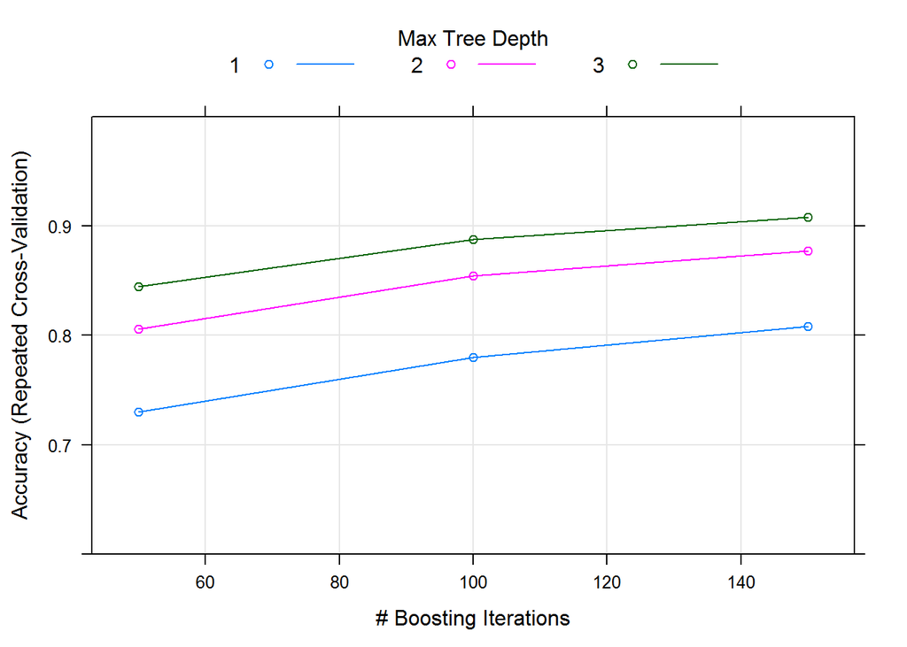

```r
plot(gbm_mod, ylim=c(0.6, 1))
```

## Decision Tree Model

We now build a model using a decision tree

```r
dt_mod <- rpart(classe~., data=train, method="class")
pred_dt <- predict(dt_mod, valid, type = "class")
cm_dt<- confusionMatrix(pred_dt, valid$classe)
cm_dt
```

```
## Confusion Matrix and Statistics
##
##           Reference
## Prediction    A    B    C    D    E
##          A 2151   65    8    2    0
##          B   57 1256   82   61    0
##          C   24  184 1256  142   57
##          D    0   13   14  933   79
##          E    0    0    8  148 1306
##
## Overall Statistics
##
##                Accuracy : 0.8797
##                  95% CI : (0.8723, 0.8868)
##     No Information Rate : 0.2845
##     P-Value [Acc > NIR] : < 2.2e-16
##
##                   Kappa : 0.8478
##  Mcnemar's Test P-Value : NA
##
## Statistics by Class:
##
##                      Class: A Class: B Class: C Class: D Class: E
## Sensitivity            0.9637   0.8274   0.9181   0.7255   0.9057
## Specificity            0.9866   0.9684   0.9372   0.9838   0.9756
## Pos Pred Value         0.9663   0.8626   0.7553   0.8980   0.8933
## Neg Pred Value         0.9856   0.9590   0.9819   0.9481   0.9787
## Prevalence             0.2845   0.1935   0.1744   0.1639   0.1838
## Detection Rate         0.2742   0.1601   0.1601   0.1189   0.1665
## Detection Prevalence   0.2837   0.1856   0.2120   0.1324   0.1863
## Balanced Accuracy      0.9752   0.8979   0.9277   0.8547   0.9407
```

[figure not shown]

```r
fancyRpartPlot(dt_mod)
```

## Random Forest Model

We now build a model using a random forest

```r
rf_mod<-train(classe~.,data=train,method="rf",preProcess="pca",trControl=trainControl(method="cv"),number=3)
```

[output not shown]

```r
pred_rf <- predict(rf_mod, valid)
cm_rf <- confusionMatrix(pred_rf, valid$classe)
cm_rf
```

```
## Confusion Matrix and Statistics
##
##           Reference
## Prediction    A    B    C    D    E
##          A 2218   36    0    0    0
##          B    4 1471   20    0    0
##          C   10   11 1348   38    0
##          D    0    0    0 1243    6
##          E    0    0    0    5 1436
##
## Overall Statistics
##
##                Accuracy : 0.9834
##                  95% CI : (0.9804, 0.9861)
##     No Information Rate : 0.2845
##     P-Value [Acc > NIR] : < 2.2e-16
##
##                   Kappa : 0.979
##  Mcnemar's Test P-Value : NA
##
## Statistics by Class:
##
##                      Class: A Class: B Class: C Class: D Class: E
## Sensitivity            0.9937   0.9690   0.9854   0.9666   0.9958
## Specificity            0.9936   0.9962   0.9909   0.9991   0.9992
## Pos Pred Value         0.9840   0.9839   0.9581   0.9952   0.9965
## Neg Pred Value         0.9975   0.9926   0.9969   0.9935   0.9991
## Prevalence             0.2845   0.1935   0.1744   0.1639   0.1838
## Detection Rate         0.2827   0.1875   0.1718   0.1584   0.1830
## Detection Prevalence   0.2873   0.1905   0.1793   0.1592   0.1837
## Balanced Accuracy      0.9937   0.9826   0.9881   0.9828   0.9975
```

## Predicting classe for the Test Set

We now obtain predictions for the quiz.

```r
test_predictions <- predict(rf_mod, testing)
test_predictions
```

```
##  [1] B A C A A E D B A A B C B A E E A B B B
## Levels: A B C D E
```